# 13_canoe_river_rads

## 13_canoe_river_rads

#### Question

1. A canoe travels 1.6 m/s **relative to the water**. A river, heading east, flows at 2.4 m/s. The canoe points at a direction 0.94 radians counterclockwise from east.

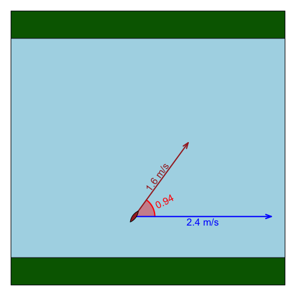

   Find the canoe’s total speed, in m/s, and direction of travel, as radians counterclockwise from east. (In other words, find the canoe’s velocity **relative to the ground**, in polar form.)
   - Speed =
   - Direction =

#### Question

2. A canoe travels 1.2 m/s **relative to the water**. A river, heading east, flows at 3.0 m/s. The canoe points at a direction 1.88 radians counterclockwise from east.

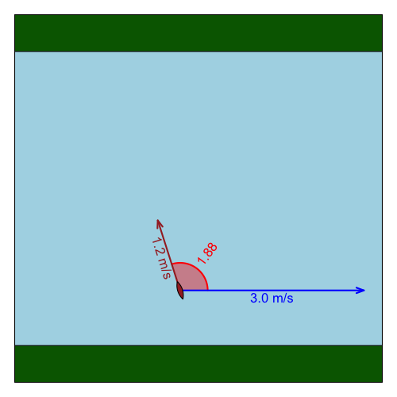

   Find the canoe’s total speed, in m/s, and direction of travel, as radians counterclockwise from east. (In other words, find the canoe’s velocity **relative to the ground**, in polar form.)
   - Speed =
   - Direction =

#### Question

3. A canoe travels 2.5 m/s **relative to the water**. A river, heading east, flows at 1.2 m/s. The canoe points at a direction 1.48 radians counterclockwise from east.

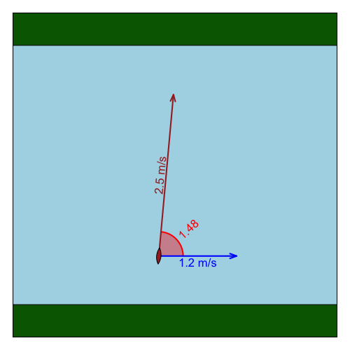

   Find the canoe’s total speed, in m/s, and direction of travel, as radians counterclockwise from east. (In other words, find the canoe’s velocity **relative to the ground**, in polar form.)
   - Speed =
   - Direction =

#### Question

4. A canoe travels 3.3 m/s **relative to the water**. A river, heading east, flows at 2.7 m/s. The canoe points at a direction 2.34 radians counterclockwise from east.

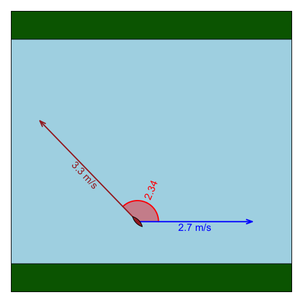

   Find the canoe’s total speed, in m/s, and direction of travel, as radians counterclockwise from east. (In other words, find the canoe’s velocity **relative to the ground**, in polar form.)
   - Speed =
   - Direction =

#### Question

5. A canoe travels 3.0 m/s **relative to the water**. A river, heading east, flows at 3.2 m/s. The canoe points at a direction 2.23 radians counterclockwise from east.

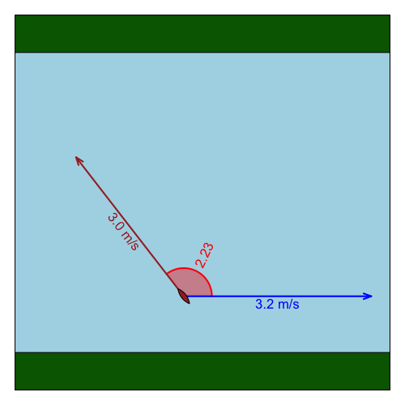

   Find the canoe’s total speed, in m/s, and direction of travel, as radians counterclockwise from east. (In other words, find the canoe’s velocity **relative to the ground**, in polar form.)
   - Speed =
   - Direction =

#### Question

6. A canoe travels 1.3 m/s **relative to the water**. A river, heading east, flows at 2.4 m/s. The canoe points at a direction 1.25 radians counterclockwise from east.

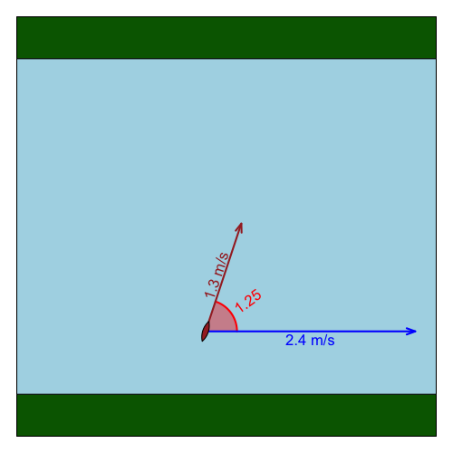

   Find the canoe’s total speed, in m/s, and direction of travel, as radians counterclockwise from east. (In other words, find the canoe’s velocity **relative to the ground**, in polar form.)
   - Speed =
   - Direction =

#### Question

7. A canoe travels 3.2 m/s **relative to the water**. A river, heading east, flows at 3.5 m/s. The canoe points at a direction 2.30 radians counterclockwise from east.

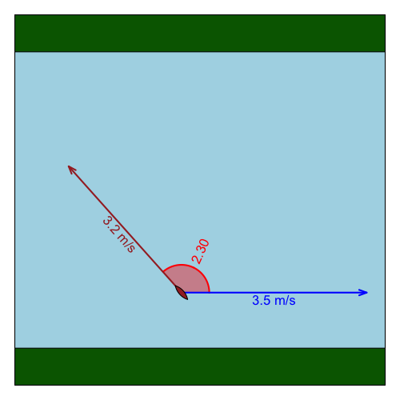

   Find the canoe’s total speed, in m/s, and direction of travel, as radians counterclockwise from east. (In other words, find the canoe’s velocity **relative to the ground**, in polar form.)
   - Speed =
   - Direction =

#### Question

8. A canoe travels 3.2 m/s **relative to the water**. A river, heading east, flows at 1.6 m/s. The canoe points at a direction 0.62 radians counterclockwise from east.

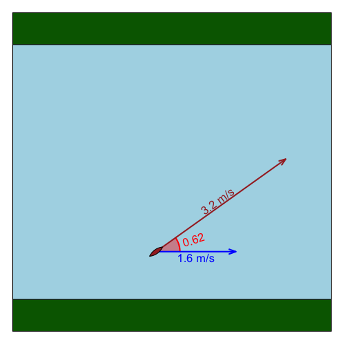

   Find the canoe’s total speed, in m/s, and direction of travel, as radians counterclockwise from east. (In other words, find the canoe’s velocity **relative to the ground**, in polar form.)
   - Speed =
   - Direction =